# Magnetfeltet rundt en solenoide

## Introduksjon

I dette essayet skal vi illustrere det magnetiske feltet rundt en solenoide og sjekke om feltet utenfor solenoiden virkelig går mot null. For å gjøre dette trenger vi å lage en numerisk modell for en solenoide som vi antar det går en konstant strøm igjennom og deretter regne ut det magnetiske feltet som den produserer rundt i rommet. En skisse av en solenoide er vist under. Vi ser fra skissen at solenoiden er bare en sammensettning av flere strukkede sirkler etter hverandre. Planen er derfor å først modellere en strømførende sirkel og beregne det magnetiske feltet denne produserer. Deretter vil vi strekke sirkelen ut slik at vi til slutt kan sette flere av dem sammen for å få en solenoide.

[figure not shown]

## Sirkel

En sirkel med radius $a$ og sentrum i origo kan beskrives med vektroen $(a\cos\theta, a\sin\theta, 0)$ som vist i figuren under, hvor $\theta$ er vinkelen utspent fra x-aksen.

[figure not shown]

Vi tar utganspunktet for å finne det magnetiske feltet som denne produserer ved å benytte Biot-Savarts lov for en strømførende leder:

$$ \mathrm{\vec{B}} = \frac{\mu_0}{4\pi} \oint_C \frac{I \mathrm{d\vec l} \times \mathrm{\vec{R}}}{R^3} $$

hvor $I$ er strømmen i kretsen og $\mathrm{d\vec l}$ er et linje element av kurven som peker i samme retning som strømmen. Vi kan skrive $\mathrm{d\vec l}$ som $\mathrm{dl}\cdot\mathrm{\hat l}$, hvor $\mathrm{dl} = a\theta$ er buelengden og $\mathrm{\hat l}$ er retningen til strømmen. Vi kaller størrelsen $I\mathrm{d\vec l}$ for et strømelement i kretsen, slik at $\mathrm{\vec{R}}$ er vektoren fra et strømelement til et vilkårlig punkt i rommet. Hvis vi definerer posisjonen til et strømelement som $\mathrm{\vec{r}'}$ og et vilkårlig punkt i rommet som $\mathrm{\vec{r}}$, så har vi at $\mathrm{\vec{R}} = \mathrm{\vec{r}} - \mathrm{\vec{r}'}$ og at $R$ er lengden på denne vektoren. Siden kretsen vår er en sirkel med radius $a$, så vil posisjonen til et strømelement tilsvare $\mathrm{\vec{r}'} = (a\cos\theta, a\sin\theta, 0)$. For øvrig har vi at $\mu_0$ er permabiliteten i vakkum, som bare er en konstant $\mu_0 = 4\pi \cdot 10^{-7}\mathrm{Ns^2/C^2}$.

For å beregne det magnetiske feltet numerisk så deler vi sirkelen opp i mange små biter og deretter regner ut det magnetiske feltet som blir dannet av hver av disse strømelementene $I\mathrm{d\vec l}$ langs sirkelen. Bidraget fra hvert strømelement tilsvarer:

$$ \mathrm{d\vec B} = \frac{\mu_0}{4\pi} \frac{I \mathrm{d\vec l} \times \vec R}{R^3} $$

Hvis vi antar at strømmen går mot klokken så betyr det at $\mathrm{d\vec l}$ vil ha samme retning som tangenten av punktene som går langs sirkelen når vi øker vinkelen $\theta$. Dette betyr at $\mathrm{\hat l}$ er den deriverte av enhetssirkelen, altså $\mathrm{\hat l} = \frac{d}{d\theta}(\cos\theta, \sin\theta, 0) = (-\sin\theta, \cos\theta, 0)$. Altså har vi at $\mathrm{d\vec l} = \mathrm{dl}(-\sin\theta, \cos\theta, 0)$. Hvis vi deler sirkelen i $N$ biter, så vil hver bit tilsvare vinkelen $\Delta\theta = 2\pi/N$. Strømelement nr $i$ langs sirkelen vil da ha en vinkel tilsvarende $\theta_i = i\cdot\Delta\theta$. Med dette har vi at $\mathrm{d\vec l}_i = \mathrm{dl}(-\sin\theta_i, \cos\theta_i, 0)$ hvor $\mathrm{dl} = a\Delta\theta$. Vi har også at $\mathrm{\vec{r}}_i' = (a\cos\theta_i, a\sin\theta_i, 0)$. Med dette har vi alt vi trenger for å modellere magnetfeltet rundt sirkel kretsen. Vi starter med å importere de nødvendige pakkene:

```python
import numpy as np
import matplotlib.pyplot as plt
```

Vi lager så en funksjon som regner ut det magnetiske feltet i et vilkårlig punkt $\vec r$ som er produsert av en sirkel med radius $a$ delt opp i $N$ biter:

```python
def magfelt(r_vec,a,N):
    B = np.array([0,0,0]) # Null magnetfelt
    dtheta = 2*np.pi/N    # Vinkelen Δ𝜃
    dl = a*dtheta         # Buelengden
    for i in range(N):
        theta = i*dtheta                                        # Vinkelen i sirkelen
        ri_vec = np.array([a*np.cos(theta),a*np.sin(theta),0])  # Posisjonen til strømelement i langs sirkelen
        R_vec = r_vec - ri_vec                                  # Vektoren fra stømelementet til punktet r
        dli_vec = dl*np.array([-np.sin(theta),np.cos(theta),0]) # Strømelement i
        dB = np.cross(dli_vec,R_vec)/np.linalg.norm(R_vec)**3   # Bidraget til magnetfeltet
        B = B + dB
    return B
```

Vi bruker denne funksjonen til å beregne det magnetiske feltet som kommer av en sirkel med radius $a=1.9$ som vi deler opp i $N = 40$ biter i xz-planet for å få et bilde av hvordan dette ser ut. Vi lar $x \in (-8, 8)$ og $z \in (-8, 8)$:

```python
a = 1.9
N = 40
L = 20
x = np.linspace(-8, 8, L)
z = np.linspace(-8, 8, L)
x, z = np.meshgrid(x, z)
Bx = x.copy()
Bz = z.copy()
for ix in range(len(x)):
    for iz in range(len(z)):
        r = np.array([x[iz, ix], 0, z[iz, ix]])
        Bx[iz, ix], By, Bz[iz, ix] = magfelt(r, a, N)
```

Visualiserer feltet:

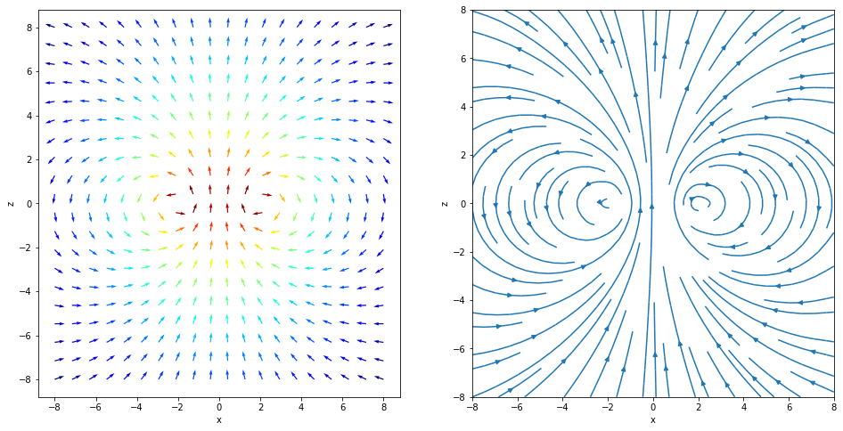

```python
nBx = Bx / np.sqrt(Bx**2 + Bz**2)
nBz = Bz / np.sqrt(Bx**2 + Bz**2)
BB = np.log10(np.sqrt(Bx**2+Bz**2))
plt.figure(figsize=(16,8))
plt.subplot(1,2,1)
plt.xlabel("x")
plt.ylabel("z")
plt.quiver(x,z,nBx,nBz,BB,cmap='jet')
plt.subplot(1,2,2)
plt.streamplot(x,z,Bx,Bz)
plt.xlabel("x")
plt.ylabel("z")
plt.show()
```

Vi ser at magnetfeltet som blir produsert av sirkelen går som løkker rundt kretsen, som er forventet oppførsel av magnetfeltet, og at feltet større innenfor sirkelen enn utenfor. Vi kan nå gå ut ifra dette til å finne det magnetiske feltet fra en utstrekt sirkel.

## Utstrekt sirkel

For å strekke ut en sirkel så innser vi at vi kun trenger å justere hvordan sirkelen oppfører seg langs z-aksen, som vi tidligere holdt konstant lik 0. Hvis vi dermed øker z-komponenten til sirkelen samtidig som vi øker vinkelen $\theta$, så vil vi ende opp med en utstrekt sirkel langs z-aksen. Vi ønsker å strekke sirkelen ut med gjevne mellomrom, noe vi kan gjøre ved å la z-komponenten til sirkelen øke sammmen med vinkelen $\theta$. Da vil vi få at den utstrekte sirkelen er beskrevet med $\mathrm{\vec{r}'} = (a\cos\theta, a\sin\theta, \theta)$. Visualiserer dette for én periode hvor $\theta$ går fra $0$ til $2\pi$ og hvor $a=1$ nedenfor:

[figure not shown]

Dette ser rimelig ut. La oss prøve å finne magnetfeltet denne ene løkken danner. Vi finner først det nye uttykket for $\mathrm{d\vec l}$ ved å derivere kurven med hennsyn på $\theta$; $\mathrm{d\vec l} = \frac{d}{d\theta}(\cos\theta, \sin\theta, \theta) = (-\sin\theta, \cos\theta, 1)$. Ser da at det eneste vi trenger å endre i funksjonen for å finne magnetfeltet er $\mathrm{\vec{r}}_i'$ og $\mathrm{d\vec l}_i$:

```python
def magfelt_sol(r_vec,a,N):
    B = np.array([0,0,0])
    dtheta = 2*np.pi/N
    dl = a*dtheta
    for i in range(N):
        theta = i*dtheta
        ri_vec = np.array([a*np.cos(theta),a*np.sin(theta),theta])
        R_vec = r_vec - ri_vec
        dli_vec = dl*np.array([-np.sin(theta),np.cos(theta),1])
        dB = np.cross(dli_vec,R_vec)/np.linalg.norm(R_vec)**3
        B = B + dB
    return B
```

For å visulisere dette så lar vi $a=1.9$ og $N=40$ som for den vanlige sirkelen, men lar heller $z \in (-6, 12)$ slik at vi ser feltet bedre når vi plotter:

```python
a = 1.9
N = 40
L = 20
x = np.linspace(-8, 8, L)
z = np.linspace(-6, 12, L)
x, z = np.meshgrid(x, z)
Bx = x.copy()
Bz = z.copy()
for ix in range(len(x)):
    for iz in range(len(z)):
        r = np.array([x[iz, ix], 0, z[iz, ix]])
        Bx[iz, ix], By, Bz[iz, ix] = magfelt_sol(r, a, N)
```

Plotter:

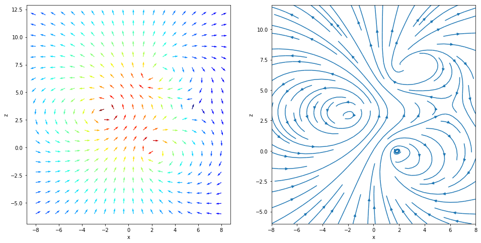

```python
nBx = Bx / np.sqrt(Bx**2 + Bz**2)
nBz = Bz / np.sqrt(Bx**2 + Bz**2)
BB = np.log10(np.sqrt(Bx**2+Bz**2))
plt.figure(figsize=(16,8))
plt.subplot(1,2,1)
plt.quiver(x,z,nBx,nBz,BB,cmap='jet')
plt.xlabel("x")
plt.ylabel("z")
plt.subplot(1,2,2)
plt.streamplot(x,z,Bx,Bz)
plt.xlabel("x")
plt.ylabel("z")
plt.show()
```

Dette ser også rimelig ut. Vi ser klart hvor strømkretsen skjærer xz-planet, som er i samsvar med modellen vår for den utstrekte sirkelen. Legger også merke til her at magnetfeltet er større innenfor kretsen enn utenfor. Med dette er vi klare for å lage en solenoide.

## Solenoide

Nå som vi har modellen for en utstrekt sirkel så gjennstår det bare å sette flere slike kurver etter hverandre for å danne en solenoide. Dette gjør vi ved å først innse at etter å la $\theta$ øke én periode ($N$ iterasjoner) så er vi tilbake der vi startet for xy-komponentene, mens z-komponenten har økt med $\theta$. Lar vi denne vinkelen forsatt øke så vil denne kurven dermed fortsette i lik stil langs z-aksen. Vi får dermed at $2N$ iterasjoner gir to utstrekte sirkler etter hverandre, $3N$ gir tre stykk osv. Vi gjør dette numerisk ved å legge til et ekstra argument $S$ for *magfelt_sol* funksjonen som sier hvor mange utstrekte sirkeler vi vil ha etter hverandre. Dette argumentet multipliserer vi så med $N$ i for-løkken:

```python
def magfelt_sol(r_vec,a,N,S):
    B = np.array([0,0,0])
    dtheta = 2*np.pi/N
    dl = a*dtheta
    for i in range(S*N):  # <------ Endring
        theta = i*dtheta
        ri_vec = np.array([a*np.cos(theta),a*np.sin(theta),theta])
        R_vec = r_vec - ri_vec
        dli_vec = dl*np.array([-np.sin(theta),np.cos(theta),1])
        dB = np.cross(dli_vec,R_vec)/np.linalg.norm(R_vec)**3
        B = B + dB
    return B
```

En solenoid med $S = 5$ svingninger er visualisert i fiugren nedenfor:

[figure not shown]

For å visualisere så beregner vi det magnetiske feltet som kommer av en solenoide med $S=5$ svingninger og radius $a=1.9$ delt opp i $SN=5\cdot40=200$ deler i xz-planet hvor $x \in (-15, 15)$ og $z \in (-5, 35)$:

```python
a = 1.9
N = 40
S = 5
L = 41
x = np.linspace(-15, 15, L)
z = np.linspace(-5, 35, L)
x,z = np.meshgrid(x,z)
Bx = x.copy()
Bz = z.copy()
for ix in range(len(x)):
    for iz in range(len(z)):
        r = np.array([x[iz,ix],0,z[iz,ix]])
        Bx[iz,ix],By,Bz[iz,ix] = magfelt_sol(r,a,N,S)
```

Plotter:

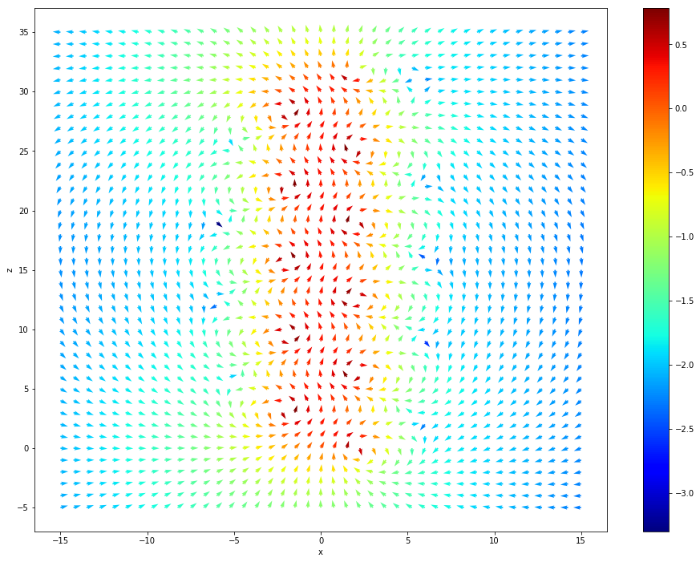

```python
nBx = Bx / np.sqrt(Bx**2 + Bz**2)
nBz = Bz / np.sqrt(Bx**2 + Bz**2)
BB = np.log10(np.sqrt(Bx**2+Bz**2))
plt.figure(figsize=(16,12))
plt.quiver(x,z,nBx,nBz,BB,cmap='jet')
plt.colorbar()
plt.xlabel("x")
plt.ylabel("z")
plt.show()
```

Slik ser altså magnetfeltet produsert av en endelig solenoide ut. Vi ser klart at magnetfeltet er mye større inne i solenoiden sammenlignet med utsiden av den hvor feltet blir gradvis svakere lengere bort fra solenoiden. Gitt skalaen i plottet er det vanskelig å si om feltet går mot null, så vi plotter i tillegg et konturplott av absoluttverdien til magnetfeltet for å prøve å svare på dette:

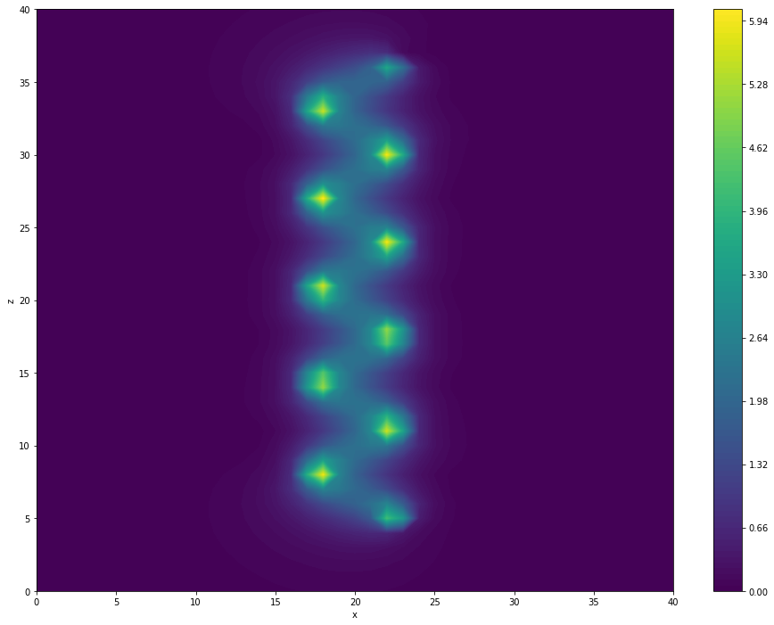

```python
B = np.sqrt(Bx**2 + Bz**2)
plt.figure(figsize=(16,12))
plt.contourf(B, 100)
plt.xlabel("x")
plt.ylabel("z")
plt.colorbar()
plt.show()
```

Her ser vi mye klarere at magnetfeltet går mot null når vi beveger oss lengere bort fra solenoiden. Vi legger merke til at magnetfeltet langs sidene utenfor solenoiden er noe større enn null, men dette ser ut til å være svært lite sammenlignet med feltet som befinner seg innenfor solenoiden.

### Kilder:

- Skissen av solenoiden i introduksjoen er tatt fra https://no.wikipedia.org/wiki/Solenoid (20.11.2022)
- Koden for magnetfeltet rundt en sirkel er inspirert av kapittel 10.1.7 fra lærerboka "Elementary Electromagnetism Using Python" av Anders Malthe-Sørenssen.